# Aspen Root Exudates

#### Outliers

##### **Within 6 groups**

```r
for (i in unique(aspen$date_id)) {
  print(paste("Outliers for group ", i))
  aspen %>% filter(date_id == i) %>%
    rm_outlier_3IQR("TOC_standardized")
}
```

```
## [1] "Outliers for group  D201910"
## [1] "Lower Bound:  -7.43123915392231"
## [1] "Upper Bound:  10.4411950392949"
## [1] "No outliers identified."
## [1] "Outliers for group  D202005"
## [1] "Lower Bound:  -2.07508315491377"
## [1] "Upper Bound:  1.67273899780446"
## [1] "No outliers identified."
## [1] "Outliers for group  D202007"
## [1] "Lower Bound:  -2.87525114537772"
## [1] "Upper Bound:  3.4448720871003"
## [1] "No outliers identified."
## [1] "Outliers for group  D202009"
## [1] "Lower Bound:  -4.2590834329585"
## [1] "Upper Bound:  4.14934490230508"
## [1] "No outliers identified."
## [1] "Outliers for group  D202105"
## [1] "Lower Bound:  -1.71981394705786"
## [1] "Upper Bound:  3.28818209007542"
## [1] "These are the rows identified as outliers:"
## # A tibble: 1 × 2
##   sample_id             TOC_standardized
##   <chr>                            <dbl>
## 1 S45-cuv5-D202105-LEAF            -5.00
## [1] "Outliers for group  D202107"
## [1] "Lower Bound:  -3.25963340608949"
## [1] "Upper Bound:  6.13976523538078"
## [1] "No outliers identified."
```

S45-cuv5-D202105-LEAF only outlier within 6 groups. Did not remove.

##### **Within 3 groups**

```r
for (i in unique(aspen$phenology)) {
  print(paste("Outliers for group ", i))
  aspen %>% filter(phenology == i) %>%
    rm_outlier_3IQR("TOC_standardized")
}
```

```
## [1] "Outliers for group  SENE"
## [1] "Lower Bound:  -2.410089079807"
## [1] "Upper Bound:  3.49576624164512"
## [1] "These are the rows identified as outliers:"
## # A tibble: 2 × 2
##   sample_id             TOC_standardized
##   <chr>                            <dbl>
## 1 S02-cuv2-D201910-SENE             6.10
## 2 S07-cuv7-D201910-SENE             3.72
## [1] "Outliers for group  LEAF"
## [1] "Lower Bound:  -4.61443353411522"
## [1] "Upper Bound:  5.14228449637239"
## [1] "These are the rows identified as outliers:"
## # A tibble: 1 × 2
##   sample_id             TOC_standardized
##   <chr>                            <dbl>
## 1 S45-cuv5-D202105-LEAF            -5.00
## [1] "Outliers for group  FULL"
## [1] "Lower Bound:  -4.542073510101"
## [1] "Upper Bound:  6.19703134680134"
## [1] "No outliers identified."
```

S45-cuv5-D202105-LEAF, S02-cuv2-D201910-SENE, S07-cuv7-D201910-SENE. did not remove

##### **Within all data**

```r
aspen %>% rm_outlier_3IQR("TOC_standardized")
```

```
## [1] "Lower Bound:  -3.78698513533432"
## [1] "Upper Bound:  4.64700590520176"
## [1] "These are the rows identified as outliers:"
## # A tibble: 3 × 2
##   sample_id             TOC_standardized
##   <chr>                            <dbl>
## 1 S02-cuv2-D201910-SENE             6.10
## 2 S45-cuv5-D202105-LEAF            -5.00
## 3 S51-cuv1-D202107-FULL             6.11
```

[output not shown]

1 S02-cuv2-D201910-SENE 6.10 2 S45-cuv5-D202105-LEAF -5.00 3 S51-cuv1-D202107-FULL 6.11 which are two of the right hand and one of the left hand QQ Plot divergences

## LMM

```r
TOC_col_LMM <- lmer(TOC_standardized ~ colonized_p + (1 | date_id), data=aspen)
summary(TOC_col_LMM)
```

```
## Linear mixed model fit by REML ['lmerMod']
## Formula: TOC_standardized ~ colonized_p + (1 | date_id)
##    Data: aspen
##
## REML criterion at convergence: 217.2
##
## Scaled residuals:
##     Min      1Q  Median      3Q     Max
## -3.3756 -0.4674 -0.0273  0.3642  3.0780
##
## Random effects:
##  Groups   Name        Variance Std.Dev.
##  date_id  (Intercept) 0.4499   0.6708
##  Residual             2.5312   1.5910
## Number of obs: 57, groups:  date_id, 6
##
## Fixed effects:
##             Estimate Std. Error t value
## (Intercept)   0.6581     0.6791   0.969
## colonized_p  -0.1410     0.9401  -0.150
##
## Correlation of Fixed Effects:
##             (Intr)
## colonized_p -0.861
```

```r
r.squaredGLMM(TOC_col_LMM)
```

```
##               R2m       R2c
## [1,] 0.0004198847 0.1512805
```

# H3.1 Contact Ratios X Phenology

**Hypothesis:** Contact ratios greater in FULL/LEAF compared to SENE

## Results

No significant difference between the phenology levels.

## Analyses

### Exploratory

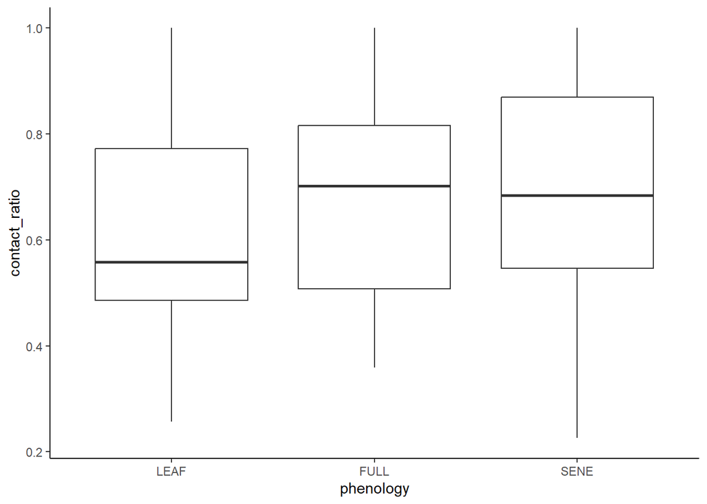

```r
p3.1.0 <- ggplot(data=aspen) + theme_classic()
p3.1.0 + geom_boxplot(aes(x=phenology, y=contact_ratio)) # variance looks good
```

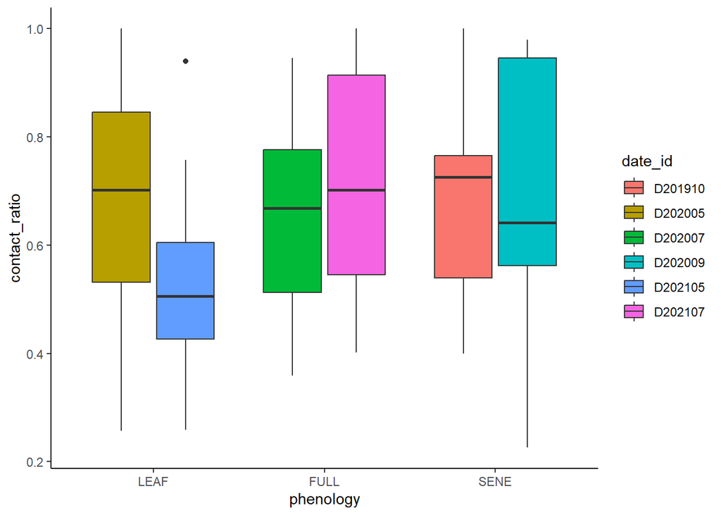

```r
p3.1.0 + geom_boxplot(aes(x=phenology, y=contact_ratio, fill = date_id)) # not terrible
```

### Outliers

#### **Within 6 groups**

```r
for (i in unique(aspen$date_id)) {
  print(paste("Outliers for group ", i))
  aspen %>% filter(date_id == i) %>%
    rm_outlier_3IQR("contact_ratio")
}
```

```
## [1] "Outliers for group  D201910"
## [1] "Lower Bound:  -0.138180825355516"
## [1] "Upper Bound:  1.44358018093379"
## [1] "No outliers identified."
## [1] "Outliers for group  D202005"
## [1] "Lower Bound:  -0.410714285714285"
## [1] "Upper Bound:  1.78720238095238"
## [1] "No outliers identified."
## [1] "Outliers for group  D202007"
## [1] "Lower Bound:  -0.279492309477885"
## [1] "Upper Bound:  1.56881746132632"
## [1] "No outliers identified."
## [1] "Outliers for group  D202009"
## [1] "Lower Bound:  -0.588848463848464"
## [1] "Upper Bound:  2.09638484638485"
## [1] "No outliers identified."
## [1] "Outliers for group  D202105"
## [1] "Lower Bound:  -0.106789577699189"
## [1] "Upper Bound:  1.1377509361348"
## [1] "No outliers identified."
## [1] "Outliers for group  D202107"
## [1] "Lower Bound:  -0.561120449418322"
## [1] "Upper Bound:  2.02094428716769"
## [1] "No outliers identified."
```

None.

#### **Within 3 groups**

```r
for (i in unique(aspen$phenology)) {
  print(paste("Outliers for group ", i))
  aspen %>% filter(phenology == i) %>%
    rm_outlier_3IQR("contact_ratio")
}
```

```
## [1] "Outliers for group  SENE"
## [1] "Lower Bound:  -0.424425287356322"
## [1] "Upper Bound:  1.83984674329502"
## [1] "No outliers identified."
## [1] "Outliers for group  LEAF"
## [1] "Lower Bound:  -0.373961038961039"
## [1] "Upper Bound:  1.63213744588745"
## [1] "No outliers identified."
## [1] "Outliers for group  FULL"
## [1] "Lower Bound:  -0.414855441311208"
## [1] "Upper Bound:  1.73842427635821"
## [1] "No outliers identified."
```

None

#### **Within all**

```r
aspen %>% rm_outlier_3IQR("contact_ratio")
```

```
## [1] "Lower Bound:  -0.422847011144883"
## [1] "Upper Bound:  1.74907970280311"
## [1] "No outliers identified."
```

[output not shown]

None, No outliers detected

### LMM

```r
contact_pheno_LMM <- lmer(contact_ratio ~ phenology + (1 | date_id), data=aspen)
r.squaredGLMM(contact_pheno_LMM)
```

```
##             R2m        R2c
## [1,] 0.02441346 0.02441346
```

Appears to overfit data due to lack of variation in sampling date factor. Simplify to linear model with no date factor

### LM with no date factor

```r
contact_pheno_LM <- lm(contact_ratio ~ phenology, data=aspen)
summary(contact_pheno_LM)
```

```
##
## Call:
## lm(formula = contact_ratio ~ phenology, data = aspen)
##
## Residuals:
##      Min       1Q   Median       3Q      Max
## -0.45644 -0.16493  0.00066  0.17201  0.39192
##
## Coefficients:
##               Estimate Std. Error t value Pr(>|t|)
## (Intercept)    0.60808    0.04893  12.428   <2e-16 ***
## phenologyFULL  0.07139    0.06919   1.032    0.307
## phenologySENE  0.07416    0.06919   1.072    0.288
## ---
## Signif. codes:  0 '***' 0.001 '**' 0.01 '*' 0.05 '.' 0.1 ' ' 1
##
## Residual standard error: 0.2188 on 57 degrees of freedom
## Multiple R-squared:  0.02525,    Adjusted R-squared:  -0.008953
## F-statistic: 0.7382 on 2 and 57 DF,  p-value: 0.4825
```

#### Testing Model Assumptions

##### Homoscedaticity

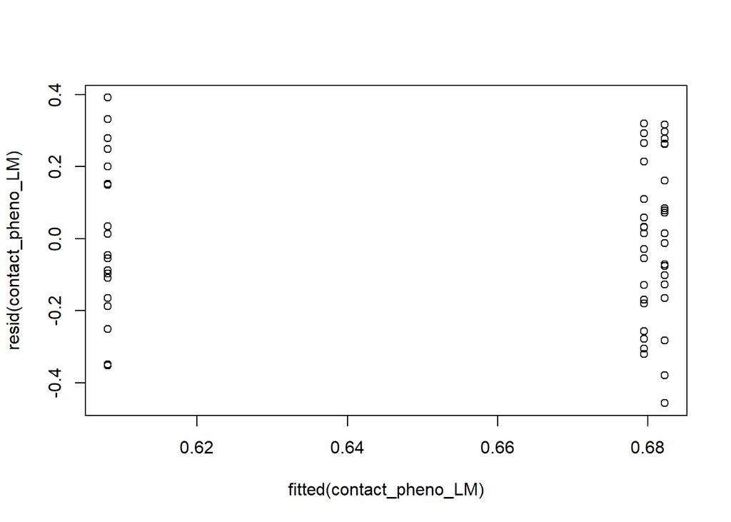

```r
plot(resid(contact_pheno_LM)~fitted(contact_pheno_LM)) # good
```

```r
levene_test(data=aspen, resid(contact_pheno_LM) ~ phenology) # p = 0.95
```

```
## # A tibble: 1 × 4
##     df1   df2 statistic     p
##   <int> <int>     <dbl> <dbl>
## 1     2    57    0.0499 0.951
```